# Ranking Best Universities in the U.S

R for Data Science @ Hult University

Francisco Pina & Christian Romero

# Set-up

```r
library(tidyverse)
```

# 1 Introduction

College tuition has increased year after year, posing challenges for students to find the most affordable institutions which have a good education level. In the UK, students have an average student debt of 30,800 USD. Students graduating in Canada have an average student debt of 20,000 USD, and in Germany, the average debt is only 2,400 USD. Meanwhile, students in the United States are graduating with far more student debt than any other country in the world. [Click to read source](https://www.studentloanreview.com/college-cost-around-the-world-infographic/#:~:text=Students%20graduating%20in%20Canada%20have,other%20country%20in%20the%20world.)

# 2 Data

This data focuses on higher education tuition costs in the United States. It consists of 5 datasets, each of which focuses on different aspects of the educational environment. Our focus will be on diversity, tuition costs and salary potential

[Data Source](https://www.kaggle.com/jessemostipak/college-tuition-diversity-and-pay?select=tuition_income.csv)

```r
diversity_school = read.csv("./diversity_school.csv")
historical_tuition = read.csv("./historical_tuition.csv")
salary_potential = read.csv("./salary_potential.csv")
tuition_cost = read.csv("./tuition_cost.csv")
tuition_income = read.csv("./tuition_income.csv")
```

• **Diversity School:** Depicts the number of people of minorities in each university.

• **Salary Potential:** Describes the potential career pay in both the early and mid-career periods. Furthermore, it also gives the percentage of students who think they will make the world a better place and the percentage of students enrolled in STEM degrees.

• **Tuition Costs:** Presents the tuition cost for the following scenarios:

*In_state_tuition* refers to costs for students from the same state where the college is. *Out_of_state_tuition* refers to costs for students from a different state where the college is.

• **Tuition Income:** Characterizes the average pricing for a degree and the average net price for students within certain income brackets

```r
tuition_income = tuition_income %>%
  rename(state_code = state)

salary_potential = salary_potential %>%
  rename(state = state_name)
```

```r
tuition_income_cost = tuition_income %>%
  left_join(tuition_cost, by = c("name", "state_code")) %>%
  left_join(diversity_school, by = c("name", "state"))
```

```r
tuition_income_salary = tuition_cost %>%
  left_join(tuition_income, by = c("name", "state_code")) %>%
  left_join(salary_potential, by = c("name", "state"))
```

# 3 Best Universities by Salary

One of the main factors that Universities take into consideration is the salary of their graduates. Organizations establish reputations with the superior performance of their graduates, consequently, salaries are a fairly consistent judgment on the worthiness of the students. Accordingly, the following section will inform which are the best places for students with low to mid income to go. Two main scenarios will be given: Students who want a STEM degree and vice-versa.

Firstly, there will be an analysis that depicts the real cost and revenue of going to certain universities. The computations below are annuities that reveal the NPV (Net Present Value) of the investment and future salary.

## 3.1 Assumptions:

• The yearly living expenses for staying in the state and for coming from outside of the state are 11’000 and 15’000 respectively.

• In order to choose if a University specializes in STEM, the criteria was that any institution with MORE than 25% students enrolled in STEM courses, was considered specialized. This treshold was chosen by analyzing the histogram of STEM graduates.A great amount of schools fall below this treshold, making 25% an ideal for above average STEM graduates.

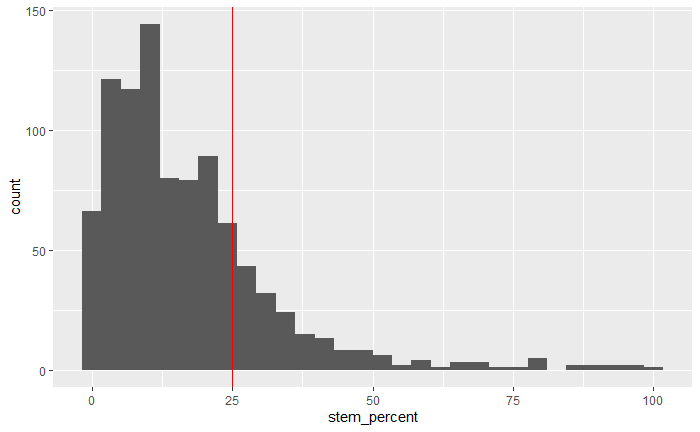

```r
salary_potential %>%
  ggplot(data=. ,aes(x=stem_percent))+
  geom_histogram() +
  geom_vline(xintercept = 25, color="red")
```

• The interest rate is 2.75% and the time periods for the annuity were 5 years of early career salary and 5 years of mid-career salary (information in dataset).

• Universities missing the number of enrolled students and the cost of tuition for lower income students will not appear in the final ranking.

• All values were assumed with low to mid income students and respective spending. Costs, interest rates and tuition may differ for different income brackets.

The cost for people that come from inside the state and for people who come from outside the state differ

```r
tuition_income_salary <- tuition_income_salary %>%
  mutate(degree_length_year = ifelse(degree_length == "2 Year",2,4))
```

```r
annuity <- function(c,r,n){

  step1 <- (1+r)^n
  step2 <- (step1 - 1) / r
  step3 <- c*step2

  return(step3)
}
```

```r
loan_rate = 0.0275
out_of_state_cost_year = 15000

tuition_income_salary <- tuition_income_salary %>%
  mutate(net_debt_out_state = out_of_state_tuition*(1+loan_rate)^degree_length_year + annuity(c = out_of_state_cost_year, r = loan_rate, n = degree_length_year))
```

```r
loan_rate = 0.0275
in_state_cost_year = 11000

tuition_income_salary <- tuition_income_salary %>%
  mutate(net_debt_in_state = in_state_tuition*(1+loan_rate)^degree_length_year + annuity(c = in_state_cost_year, r = loan_rate, n = degree_length_year))
```

Computing the PV of the next 10 years of salary of an average graduate

```r
early_career_years = 5
mid_career_years = 5
loan_rate = 0.0275


salary_pv <- function(c1,c2,r,n,m){

  step1_1 <- (1+r)^n
  step1_2 <- (step1_1 - 1) / r
  step1_3 <- c1*step1_2

  step2_1 <- (1+r)^m
  step2_2 <- (step2_1 - 1) / r
  step2_3 <- c2*step2_2

  result <- step1_3 + step2_3/step1_1

  return(result)

}

tuition_income_salary <- tuition_income_salary %>%
  filter(early_career_pay != "NA") %>%
  mutate(pv_salary = salary_pv(c1 = early_career_pay, c2 = mid_career_pay, r = loan_rate, n = early_career_years, m = mid_career_years) /((1+loan_rate)^degree_length_year))
```

Computing the NPV of the salary minus the PV of expenses

```r
tuition_income_salary <- tuition_income_salary %>%
  mutate(npv_tuition_in_state = pv_salary - net_debt_in_state) %>%
  mutate(npv_tuition_out_state = pv_salary - net_debt_out_state)
```

What is considered to be a University that specializes in STEM courses?

We found with the following distribution that universities with over 25% of students enrolled in STEM courses, are considered to be specialized in such

Separating STEM universities from NON-STEM and turning them into vectors with the objective of filtering our results.

```r
tuition_income_salary <- tuition_income_salary %>%
  mutate(is_stem = ifelse(stem_percent >= 25,1,0))

with_stem = tuition_income_salary %>%
  filter(is_stem==1) %>%
  .$name

low_stem = tuition_income_salary %>%
  filter(is_stem==0) %>%
  .$name
```

## 3.2 Rankings

Before showing the rankings, it is interesting to observe the average salary of high STEM graduates universities vs low STEM graduates universities

### 3.2.1 Average salary of STEM and non-STEM degrees

```r
tuition_income_salary %>%
  group_by(is_stem) %>%
  summarise(Average_PV_Salary = mean(pv_salary))
```

| is_stem | Average_PV_Salary |
| --- | --- |
| 0 | 597772.6 |
| 1 | 707626.3 |

### 3.2.2 Rank of the non-STEM universities (For lower income students)

```r
rank_table_no_stem <- tuition_income_salary %>%
  filter(name %in% low_stem ) %>%
  filter(year %in% c(2018) & income_lvl %in% c("0 to 30,000")) %>%
  filter(campus == "On Campus")

rank_table_no_stem <- rank_table_no_stem[order(-rank_table_no_stem$pv_salary),]

rank_table_no_stem$ranking <- NA
rank_table_no_stem$ranking <- 1:nrow(rank_table_no_stem)

rank_table_no_stem %>%
  slice_max(pv_salary, n=20)%>%
  select(ranking,name, state_code, net_debt_in_state, net_debt_out_state, pv_salary)
```

| ranking | name | state_code | net_debt_in_state | net_debt_out_state | pv_salary |
| --- | --- | --- | --- | --- | --- |
| 1 | Yale University | CT | 105402.72 | 122074.90 | 905501.8 |
| 2 | University of Pennsylvania | PA | 107803.61 | 124475.80 | 899142.1 |
| 3 | Babson College | MA | 102810.11 | 119482.29 | 894936.7 |
| 4 | Claremont McKenna College | CA | 106489.47 | 123161.66 | 843587.4 |
| 5 | Washington and Lee University | VA | 104315.96 | 120988.15 | 822160.7 |
| 6 | MCPHS University | MA | 82302.19 | 98974.38 | 816367.2 |
| 7 | University of Southern California | CA | 108518.08 | 125190.27 | 804766.1 |
| 8 | Villanova University | PA | 105266.73 | 121938.92 | 803057.7 |
| 9 | Vanderbilt University | TN | 101374.48 | 118046.66 | 802824.2 |
| 10 | Bentley University | MA | 101445.81 | 118118.00 | 798165.9 |

[output cut: 10 more lines]

### 3.2.3 Rank of the STEM Universities (for low income students)

```r
rank_table_stem <- tuition_income_salary %>%
  filter(name %in% with_stem ) %>%
  filter(year %in% c(2018) & income_lvl %in% c("0 to 30,000")) %>%
  filter(campus == "On Campus")

rank_table_stem <- rank_table_stem[order(-rank_table_stem$pv_salary),]

rank_table_stem$ranking <- NA
rank_table_stem$ranking <- 1:nrow(rank_table_stem)

rank_table_stem %>%
  slice_max(pv_salary, n=20)%>%
  select(ranking,name, state_code,net_debt_in_state,net_debt_out_state,pv_salary)
```

| ranking | name | state_code | net_debt_in_state | net_debt_out_state | pv_salary |
| --- | --- | --- | --- | --- | --- |
| 1 | Harvey Mudd College | CA | 109243.70 | 125915.89 | 1075532.4 |
| 2 | Massachusetts Institute of Technology | MA | 103621.55 | 120293.74 | 1051269.1 |
| 3 | California Institute of Technology | CA | 104212.30 | 120884.49 | 1025944.6 |
| 4 | Stanford University | CA | 103088.76 | 119760.95 | 975288.8 |
| 5 | Colorado School of Mines | CO | 66986.18 | 105527.23 | 936000.5 |
| 6 | Carnegie Mellon University | PA | 107670.97 | 124343.16 | 922938.5 |
| 7 | Rose-Hulman Institute of Technology | IN | 101435.78 | 118107.96 | 917431.5 |
| 8 | Worcester Polytechnic Institute | MA | 102170.32 | 118842.50 | 909554.8 |
| 9 | Santa Clara University | CA | 103486.68 | 120158.87 | 888708.3 |
| 10 | Lehigh University | PA | 104845.41 | 121517.59 | 884329.6 |

[output cut: 10 more lines]

### 3.2.4 Average amount saved by staying in the same state

Besides giving just the ranking of the best Universities sor same-state students, we want to show you on average how much would students save if they choose not to move to a different state to study.

```r
tuition_income_salary %>%
  summarise(avg_saving_in_state = mean(net_debt_out_state - net_debt_in_state))
```

| avg_saving_in_state |
| --- |
| 21752.81 |

### 3.2.5 Average Payback Period in Years -> Assuming yearly payments = 10% of Salary

Another measure of profitability is to calculate the payback period of the investment, in this case, student debt incurred in order to access higher education. There isn’t a difference between high STEM graduates universities and low STEM graduates universities, but there is almost a 3 year difference in payback if you decide to stay in-state vs out-of-state.

```r
tuition_income_salary %>%
  filter(year %in% c(2018) & income_lvl %in% c("0 to 30,000")) %>%
  filter(campus == "On Campus") %>%
  group_by(is_stem) %>%
  summarise(Payback_Period_Out_State = mean(net_debt_out_state/((early_career_pay/2 + mid_career_pay/2)/10)),Payback_Period_In_State = mean(net_debt_in_state/((early_career_pay/2 + mid_career_pay/2)/10)))
```

| is_stem | Payback_Period_Out_State | Payback_Period_In_State |
| --- | --- | --- |
| 0 | 13.93324 | 10.73657 |
| 1 | 13.19205 | 10.55072 |

### 3.2.6 Universities with the highest salaries in each state (No STEM)

This is a ranking of the Universities with highest salaries for each state where the percentage of STEM graduates is low. These are universities which mostly focus on Humanities, Artes, Literature and Management.

```r
rank_table_no_stem %>%
  filter(name %in% low_stem ) %>%
  filter(year %in% c(2018) & income_lvl %in% c("0 to 30,000")) %>%
  filter(campus == "On Campus") %>%
  group_by(state) %>%
  slice_max(pv_salary) %>%
  select(ranking, name, state, net_debt_in_state, net_debt_out_state, pv_salary)
```

| ranking | name | state | net_debt_in_state | net_debt_out_state | pv_salary |
| --- | --- | --- | --- | --- | --- |
| 195 | Samford University | Alabama | 81126.27 | 97798.45 | 603900.0 |
| 40 | University of Alaska Fairbanks | Alaska | 54862.45 | 89558.05 | 701374.1 |
| 57 | University of Arizona | Arizona | 59766.78 | 103077.30 | 683845.2 |
| 94 | University of Arkansas | Arkansas | 56025.00 | 90573.47 | 654368.5 |
| 4 | Claremont McKenna College | California | 106489.47 | 123161.66 | 843587.4 |
| 41 | University of Denver | Colorado | 102199.30 | 118871.48 | 698916.2 |
| 1 | Yale University | Connecticut | 105402.72 | 122074.90 | 905501.8 |
| 37 | University of Delaware | Delaware | 61096.52 | 100763.34 | 713902.1 |
| 67 | University of Miami | Florida | 101831.47 | 118503.65 | 678525.6 |
| 20 | Emory University | Georgia | 103035.26 | 119707.45 | 752362.7 |

[output cut: 29 more lines]

# 4 Diversity Ranking

While future salary prospect is an important factor when deciding which school to go for, it is also important to take into consideration the measure of diversity at the school.

```r
minority = diversity_school %>%
  mutate(pct = enrollment / total_enrollment) %>%
  filter(category == "Total Minority")
```

We consider the “Total Minority %” as a measure of how schools work towards more inclusive environments. Here are some of the reasons why diversity matters:

- Diversity enriches whe educational experience: We learn from those whose experiences, beliefs, and perspectives are different from our own, and these lessons can be taught best in a richly diverse intellectual and social environment. (ACE Board of Directors, 2012)
- It enhances America’s economic competitiveness. Sustaining the nation’s prosperity in the 21st century requires us to make effective use of the talents and abilities of all our citizens, in work settings that bring together individuals from diverse backgrounds and cultures. (ACE Board of Directors, 2012)

```r
minority %>%
  slice_max(pct, n=5) %>%
  select(name, total_enrollment, enrollment, pct)
```

| name | total_enrollment | enrollment | pct |
| --- | --- | --- | --- |
| Lane College | 1262 | 1262 | 1 |
| Haskell Indian Nations University | 808 | 808 | 1 |
| Southwestern Indian Polytechnic Institute | 481 | 481 | 1 |
| College of the Muscogee Nation | 188 | 188 | 1 |
| Maple Springs Baptist Bible College & Seminary | 99 | 99 | 1 |
| Carver College | 88 | 88 | 1 |
| Professional Hands Institute | 37 | 37 | 1 |
| Interactive Learning Systems at Pasadena (Tex.) | 34 | 34 | 1 |
| Interactive Learning Systems-North Houston | 11 | 11 | 1 |
| ITT Technical Institute at West Covina (Calif.) | 8 | 8 | 1 |

```r
minority %>%
  filter(enrollment >450) %>%
  filter(name %in% with_stem) %>%
  filter(pct > 0.4 & pct < 0.6) %>%
  slice_max(pct, n=10)
```

| name | total_enrollment | state | category | enrollment | pct |
| --- | --- | --- | --- | --- | --- |
| Agnes Scott College | 873 | Georgia | Total Minority | 462 | 0.5292096 |
| University of Illinois at Chicago | 27969 | Illinois | Total Minority | 13568 | 0.4851085 |
| University of Houston-Clear Lake | 8665 | Texas | Total Minority | 3964 | 0.4574726 |
| Swarthmore College | 1542 | Pennsylvania | Total Minority | 671 | 0.4351492 |
| Wellesley College | 2323 | Massachusetts | Total Minority | 1010 | 0.4347826 |
| Amherst College | 1792 | Massachusetts | Total Minority | 779 | 0.4347098 |
| University of Bridgeport | 5191 | Connecticut | Total Minority | 2205 | 0.4247736 |
| Pomona College | 1650 | California | Total Minority | 682 | 0.4133333 |

```r
minority %>%
  filter(enrollment > 450) %>%
  filter(name %in% low_stem ) %>%
  filter(pct > 0.4 & pct < 0.6) %>%
  slice_max(pct, n=10)
```

| name | total_enrollment | state | category | enrollment | pct |
| --- | --- | --- | --- | --- | --- |
| Georgia State University | 32556 | Georgia | Total Minority | 19336 | 0.5939305 |
| Kentucky State University | 1895 | Kentucky | Total Minority | 1097 | 0.5788918 |
| Nova Southeastern University | 24148 | Florida | Total Minority | 13498 | 0.5589697 |
| Hawaii Pacific University | 5827 | Hawaii | Total Minority | 3169 | 0.5438476 |
| University of Baltimore | 6422 | Maryland | Total Minority | 3376 | 0.5256929 |
| Barry University | 8518 | Florida | Total Minority | 4431 | 0.5201925 |
| Florida Atlantic University | 30297 | Florida | Total Minority | 15268 | 0.5039443 |
| Faulkner University | 3335 | Alabama | Total Minority | 1674 | 0.5019490 |
| Albertus Magnus College | 1550 | Connecticut | Total Minority | 767 | 0.4948387 |
| Webster University | 16769 | Missouri | Total Minority | 8219 | 0.4901306 |

# 5 Conclusion

We would like to use this data for a future analysis regarding prediction of salaries. We consider that we have laid an interesting foundation and that we could think of a model that taking into consideration factors such as in-state/out-of-state, high stem/low stem, among some others, we could try to predict average salaries for graduates.